# Logistic Regression Practice

Tam Nguyen

### Part A: Using MedGPA to work with untabulated data

## 1. Open the MedGPA data set (from the Stat2Data) in R and use head(MedGPA) to investigate the data.

```r
library(mosaic);
library(Stat2Data);
data(MedGPA);
Tab = table(MedGPA$Sex,MedGPA$Acceptance)
Tab
```

```
##
##      0  1
##   F 10 18
##   M 15 12
```

## 3. Acceptance: MCAT scores

The variable “MCAT” contains the total MCAT scores for these 55 students.

1. The code below will calculate the proportion of successes within each MCAT score:

```r
tab <- xtabs(~MCAT+Acceptance,data=MedGPA)
prop <- tab[,2]/(tab[,2] + tab[,1])
```

2. Now plot these proportions against the MCAT scores:

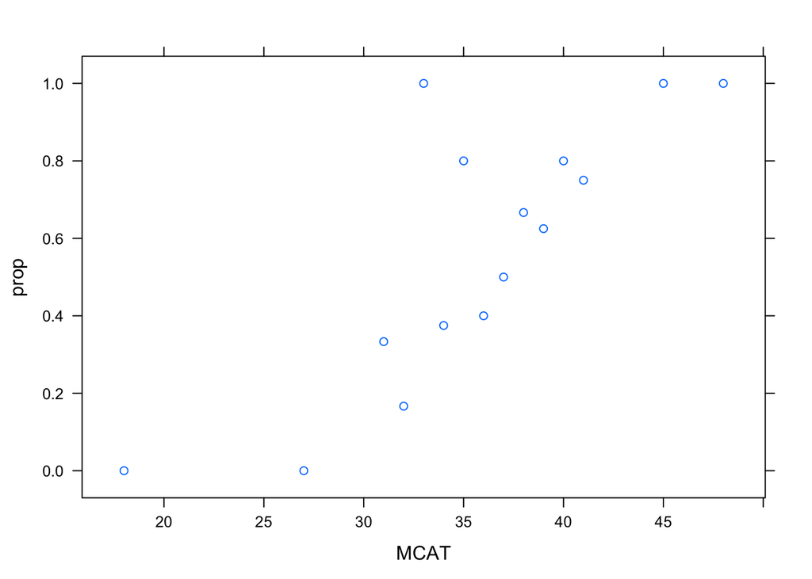

```r
xyplot(prop~sort(unique(MedGPA$MCAT)), xlab="MCAT")
```

3. Does it look like a logistic regression model will be helpful here? Why or why not?
- The data points mostly follow an S-curve, which means a logistic regression model will be a good fit for this dataset.

## 4. Checking Linearity

Notice (from tab) that most of our cells contain 0, 1, or 2. We could do the “trick” again and add 0.5 to all the successes and failures, but another way of dealing with it is the procedure described on p. 472- 474 (Example 9.12), which is what we’ll use below…

1. First, divide the range of MCAT scores into intervals with roughly equal numbers of cases. I have made (what I think is) a judicious division below into 5 intervals (however, there is no “right” number of intervals in these cases!).  
   Fill in the rest of the table, using tab to help you.

```r
slice1 = MedGPA[(MedGPA[,10]>17) & (MedGPA[,10]<33), ]
summary(slice1)
```

```
##  Accept   Acceptance     Sex        BCPM            GPA
##  A:2    Min.   :0.0000   F:4   Min.   :2.410   Min.   :2.720
##  D:9    1st Qu.:0.0000   M:7   1st Qu.:3.175   1st Qu.:3.275
##         Median :0.0000         Median :3.350   Median :3.400
##         Mean   :0.1818         Mean   :3.256   Mean   :3.329
##         3rd Qu.:0.0000         3rd Qu.:3.535   3rd Qu.:3.525
##         Max.   :1.0000         Max.   :3.760   Max.   :3.680
##
##        VR               PS               WS            BS
##  Min.   : 6.000   Min.   : 5.000   Min.   :4.0   Min.   : 6.000
##  1st Qu.: 7.000   1st Qu.: 8.000   1st Qu.:4.0   1st Qu.: 8.000
##  Median : 8.000   Median : 8.000   Median :5.5   Median : 8.000
##  Mean   : 8.364   Mean   : 8.091   Mean   :5.6   Mean   : 8.455
##  3rd Qu.:10.000   3rd Qu.: 9.000   3rd Qu.:6.0   3rd Qu.: 9.500
##  Max.   :11.000   Max.   :10.000   Max.   :9.0   Max.   :10.000
##                                    NA's   :1
##       MCAT         Apps
##  Min.   :18   Min.   : 4.000
##  1st Qu.:31   1st Qu.: 5.500
##  Median :32   Median : 7.000
##  Mean   :30   Mean   : 7.818
##  3rd Qu.:32   3rd Qu.: 9.500
##  Max.   :32   Max.   :15.000
##
```

```r
slice2 = MedGPA[(MedGPA[,10]>32) & (MedGPA[,10]<35), ]
summary(slice2)
```

```
##  Accept   Acceptance     Sex        BCPM           GPA
##  A:4    Min.   :0.0000   F:7   Min.   :3.14   Min.   :3.090
##  D:5    1st Qu.:0.0000   M:2   1st Qu.:3.19   1st Qu.:3.370
##         Median :0.0000         Median :3.43   Median :3.480
##         Mean   :0.4444         Mean   :3.45   Mean   :3.508
##         3rd Qu.:1.0000         3rd Qu.:3.67   3rd Qu.:3.700
##         Max.   :1.0000         Max.   :3.86   Max.   :3.890
##        VR               PS               WS              BS
##  Min.   : 7.000   Min.   : 8.000   Min.   :5.000   Min.   : 9.000
##  1st Qu.: 7.000   1st Qu.: 9.000   1st Qu.:6.000   1st Qu.: 9.000
##  Median : 9.000   Median :10.000   Median :6.000   Median : 9.000
##  Mean   : 8.778   Mean   : 9.333   Mean   :6.556   Mean   : 9.222
##  3rd Qu.:10.000   3rd Qu.:10.000   3rd Qu.:8.000   3rd Qu.: 9.000
##  Max.   :11.000   Max.   :10.000   Max.   :8.000   Max.   :10.000
##       MCAT            Apps
##  Min.   :33.00   Min.   : 5
##  1st Qu.:34.00   1st Qu.: 6
##  Median :34.00   Median :11
##  Mean   :33.89   Mean   :12
##  3rd Qu.:34.00   3rd Qu.:14
##  Max.   :34.00   Max.   :24
```

```r
slice3 = MedGPA[(MedGPA[,10]>34) & (MedGPA[,10]<37), ]
summary(slice3)
```

```
##  Accept   Acceptance  Sex        BCPM            GPA              VR
##  A:6    Min.   :0.0   F:4   Min.   :2.750   Min.   :3.040   Min.   : 8.0
##  D:4    1st Qu.:0.0   M:6   1st Qu.:3.500   1st Qu.:3.435   1st Qu.: 8.0
##         Median :1.0         Median :3.660   Median :3.680   Median : 8.5
##         Mean   :0.6         Mean   :3.539   Mean   :3.587   Mean   : 9.0
##         3rd Qu.:1.0         3rd Qu.:3.748   3rd Qu.:3.757   3rd Qu.:10.0
##         Max.   :1.0         Max.   :3.890   Max.   :3.890   Max.   :11.0
##        PS             WS              BS             MCAT
##  Min.   : 8.0   Min.   : 4.00   Min.   : 6.00   Min.   :35.0
##  1st Qu.: 9.0   1st Qu.: 6.25   1st Qu.:10.00   1st Qu.:35.0
##  Median : 9.5   Median : 7.50   Median :10.00   Median :35.5
##  Mean   : 9.5   Mean   : 7.20   Mean   : 9.80   Mean   :35.5
##  3rd Qu.:10.0   3rd Qu.: 8.00   3rd Qu.:10.75   3rd Qu.:36.0
##  Max.   :11.0   Max.   :10.00   Max.   :11.00   Max.   :36.0
##       Apps
##  Min.   : 1.0
##  1st Qu.: 5.0
##  Median : 6.5
##  Mean   : 7.2
##  3rd Qu.: 7.0
##  Max.   :18.0
```

```r
slice4 = MedGPA[(MedGPA[,10]>36) & (MedGPA[,10]<40), ]
summary(slice4)
```

```
##  Accept   Acceptance     Sex        BCPM            GPA
##  A:8    Min.   :0.0000   F:7   Min.   :3.100   Min.   :3.140
##  D:5    1st Qu.:0.0000   M:6   1st Qu.:3.260   1st Qu.:3.440
##         Median :1.0000         Median :3.510   Median :3.580
##         Mean   :0.6154         Mean   :3.511   Mean   :3.582
##         3rd Qu.:1.0000         3rd Qu.:3.590   3rd Qu.:3.670
##         Max.   :1.0000         Max.   :4.000   Max.   :3.970
##        VR              PS               WS              BS
##  Min.   : 9.00   Min.   : 8.000   Min.   :6.000   Min.   : 8.000
##  1st Qu.:10.00   1st Qu.: 9.000   1st Qu.:8.000   1st Qu.: 9.000
##  Median :11.00   Median :10.000   Median :8.000   Median :10.000
##  Mean   :10.85   Mean   : 9.846   Mean   :7.923   Mean   : 9.846
##  3rd Qu.:11.00   3rd Qu.:11.000   3rd Qu.:8.000   3rd Qu.:11.000
##  Max.   :13.00   Max.   :12.000   Max.   :9.000   Max.   :12.000
##       MCAT            Apps
##  Min.   :37.00   Min.   : 1.000
##  1st Qu.:38.00   1st Qu.: 6.000
##  Median :39.00   Median : 7.000
##  Mean   :38.46   Mean   : 8.154
##  3rd Qu.:39.00   3rd Qu.:12.000
##  Max.   :39.00   Max.   :17.000
```

```r
slice5 = MedGPA[(MedGPA[,10]>39) & (MedGPA[,10]<49), ]
summary(slice5)
```

```
##  Accept   Acceptance     Sex        BCPM            GPA
##  A:10   Min.   :0.0000   F:6   Min.   :3.220   Min.   :3.240
##  D: 2   1st Qu.:1.0000   M:6   1st Qu.:3.665   1st Qu.:3.672
##         Median :1.0000         Median :3.765   Median :3.830
##         Mean   :0.8333         Mean   :3.719   Mean   :3.733
##         3rd Qu.:1.0000         3rd Qu.:3.890   3rd Qu.:3.890
##         Max.   :1.0000         Max.   :4.000   Max.   :3.970
##        VR              PS              WS              BS
##  Min.   :10.00   Min.   : 8.00   Min.   : 6.00   Min.   :10.00
##  1st Qu.:10.75   1st Qu.:10.75   1st Qu.: 7.75   1st Qu.:10.00
##  Median :11.00   Median :11.50   Median : 8.00   Median :11.00
##  Mean   :11.25   Mean   :11.50   Mean   : 8.00   Mean   :11.33
##  3rd Qu.:12.00   3rd Qu.:13.00   3rd Qu.: 8.25   3rd Qu.:12.00
##  Max.   :13.00   Max.   :14.00   Max.   :10.00   Max.   :14.00
##       MCAT            Apps
##  Min.   :40.00   Min.   : 3.000
##  1st Qu.:40.00   1st Qu.: 5.000
##  Median :41.00   Median : 5.500
##  Mean   :42.08   Mean   : 7.333
##  3rd Qu.:42.00   3rd Qu.: 8.750
##  Max.   :48.00   Max.   :17.000
```

1. Interpret the odds ratio for an increase in MCAT score from the 35 – 36 range to the 37 – 39 range.
- The odds of picking a student who has MCAT in range 37-39 getting accepted to a med school is 106.7% of the odd of picking a student who has MCAT in range 35-36 getting accepted to a med school.
2. Looking at the odds ratios, does it look like the logistic model’s linearity constraint is reasonable? Why or why not?
- The odds ratio is greater than 1, it describes a positive relationship. The positive relationship means that as MCAT score “increases,” the odds of being accepted increases.
- However, even when there exist a positive relationship between the MCAT score and the acceptance into med school, the order of odds ratios does not have a constraint linearity. It ranges from 1.067 to 3.64
3. Create two vectors from the table above: “means”, that contains the range means; and “odds”, that contains the odds from each group. You can create these vectors easily using (for example)

```r
means <- c(30, 33.89, 35.5, 38.46, 42.08)
odds <- c(2/9,4/5, 6/4, 8/5,10/2)
```

4. Use (plot(log(odds)~means, type=“o”)( to make a scatterplot of log(odds) vs. MCAT score. What are we looking for in this plot? Does it look like a logistic regression model is appropriate in this case? Why or why not?

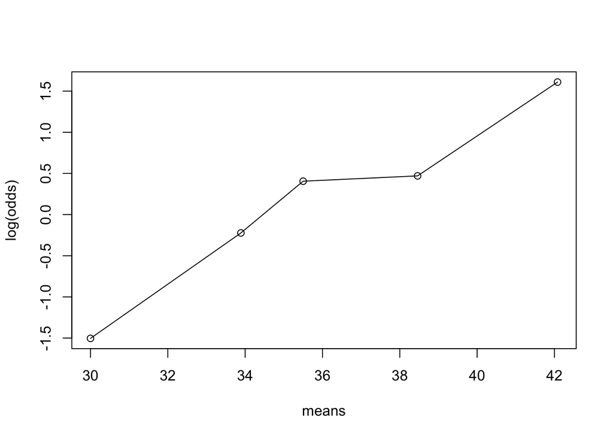

```r
plot(log(odds)~means, type="o")
```

- The plot above is linear so logistic regression is a good model for this dataset.
- There is a small deviation at the means 38~40(MCAT Score), but it doesn’t show significant

## 5. Fitting a Logistic Regression Model in R: untabulated data

1. Fit a logistic regression model with Acceptance as the response variable and MCAT as the explanatory variable. Save this model as “mcat.log” for future use.

```r
mcat.log = glm(Acceptance ~ MCAT, data=MedGPA, family=binomial)
summary(mcat.log)
```

```
##
## Call:
## glm(formula = Acceptance ~ MCAT, family = binomial, data = MedGPA)
##
## Deviance Residuals:
##     Min       1Q   Median       3Q      Max
## -1.7878  -1.0330   0.4256   0.9225   1.6601
##
## Coefficients:
##             Estimate Std. Error z value Pr(>|z|)
## (Intercept) -8.71245    3.23645  -2.692  0.00710 **
## MCAT         0.24596    0.08938   2.752  0.00592 **
## ---
## Signif. codes:  0 '***' 0.001 '**' 0.01 '*' 0.05 '.' 0.1 ' ' 1
##
## (Dispersion parameter for binomial family taken to be 1)
##
##     Null deviance: 75.791  on 54  degrees of freedom
## Residual deviance: 64.697  on 53  degrees of freedom
## AIC: 68.697
##
## Number of Fisher Scoring iterations: 4
```

2. What is the slope of the fitted model?
- 0.24596
3. Compute e^(slope). What is the interpretation of this quantity?

```r
exp(0.24596)
```

```
## [1] 1.278848
```

- The odds ratio is 1.2789.
- With every one point MCAT increase, we expect the odds of an individual to be accapted into med school is 127.9% of the odds of an individual to be accepted into med school with an MCAT score of one point lower.

## 6. Visualizing the Logistic Model: 2 ways

1. On the “linearized” plot of log(odds) vs. MCAT (from part #5a), you can plot the (straight-line) slope, as in Figures 9.12 and 9.13. To do this,

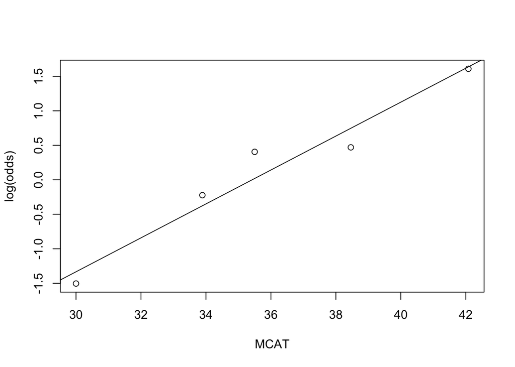

```r
plot(log(odds)~means, xlab="MCAT")  #Note the use of plot, not xyplot!
abline(reg=mcat.log)  #add the regression line from mcat.log to the plot
```

Does it look like this model is a good fit to the data?

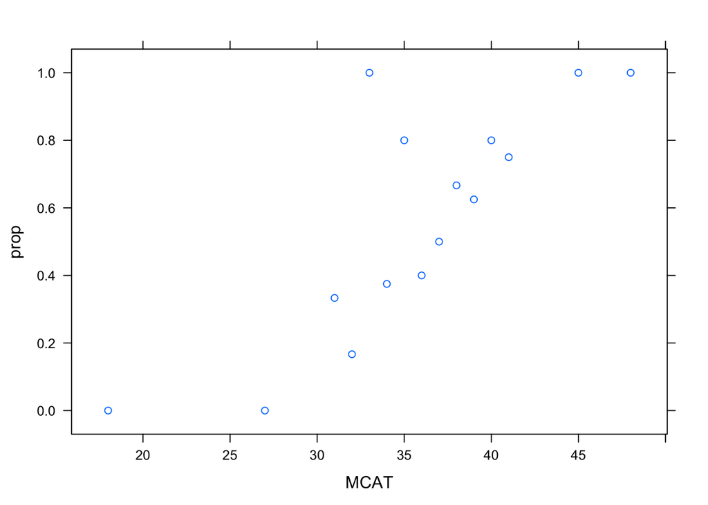

```r
xyplot(prop~sort(unique(MedGPA$MCAT)), xlab="MCAT")
```

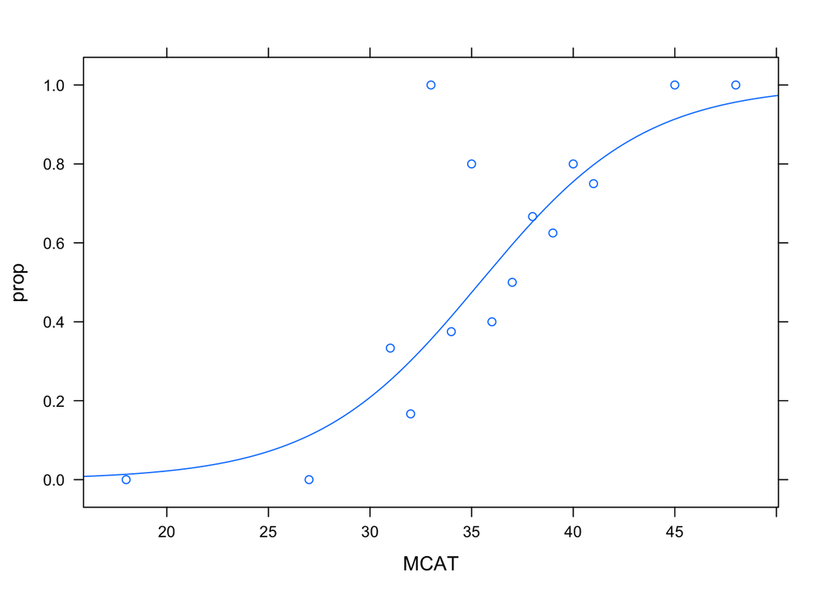

```r
fit <- makeFun(mcat.log)
plotFun(fit(MCAT)~MCAT, add=TRUE)
```

In the MCAT file, the data was in “long form”: one row for each individual. We tabulated it just to visualize it and fill in our table. What if the data is already tabulated into a table (“short form”), and we don’t have the long form?

## 3. Create the table in R

```r
cancer.tab <- matrix(data=c(2,9,14,3,8,9,3,3,9,4),nrow=2, ncol=5) #this creates the table, but without any variable labels
rownames(cancer.tab) <-c("Died","Survived") #labels the rows
colnames(cancer.tab) <-c("Breast", "Bronchus", "Colon", "Ovary", "Stomach") #labels the columns
cancer.tab #check out the pretty table!
```

```
##          Breast Bronchus Colon Ovary Stomach
## Died          2       14     8     3       9
## Survived      9        3     9     3       4
```

## 4. Fitting the Logistic Model in R: tabulated data

First, we need to change the tabulated data to what we call “semi-tabulated”: there is not a separate row for each individual, but there are separate rows for those who survived and those who died. We do this using the ‘melt’ function, which lives in the ‘reshape2’ package.

1. Install and load the ‘reshape2’ package now.

```r
library(reshape2) ;
```

2. To create the semi-tabulated version of the data, type

```r
melt(cancer.tab)
```

```
##        Var1     Var2 value
## 1      Died   Breast     2
## 2  Survived   Breast     9
## 3      Died Bronchus    14
## 4  Survived Bronchus     3
## 5      Died    Colon     8
## 6  Survived    Colon     9
## 7      Died    Ovary     3
## 8  Survived    Ovary     3
## 9      Died  Stomach     9
## 10 Survived  Stomach     4
```

Make sure you understand what has been done here! ‘Var1’ now contains information about survival (the response variable) and ‘Var2’ is the type of cancer (the explanatory variable). The ‘value’ variable contains the frequencies (counts) within each of those sub-groups.

So in our case, the code is:

```r
cancer.log <- glm(Var1~Var2, weights=value, data=melt(cancer.tab), family = binomial)
```

## 5. Interpretation

```r
(9/8)/(9/2)
```

```
## [1] 0.25
```